# Analyzing RNA-seq data with DESeq2

### Getting phenotypic (sample) data

This is the information on the samples that relate to the columns of the cnts dataframe. You need to look carefully at this table to learn the exp design and to fix the colnames tof the cnts dataframe.

```r
col_data <- pData(eset)
rownames(col_data) ## these are the series numbers
```

```
##  [1] "GSM1973695" "GSM1973696" "GSM1973697" "GSM1973698" "GSM1973699"
##  [6] "GSM1973700" "GSM1973701" "GSM1973702" "GSM1973703" "GSM1973704"
## [11] "GSM1973705" "GSM1973706"
```

### colnames of the cnts dataframe

The colnames of the cnts matrix are a combination of genotype, treatment and zeitgeber. In order to match the right sample_names (rowname) of colData with the right column name of `cnts` I create a new col_data dataframe with less columns and an addiotional column that is a united column of genetype, treatment and zeitgeber. I will use lowercase and set the colnames of the `cnts` also to lowercase. Than we add the new united column (after some cleaning and renaming) as rownames to the new coldata object. We select the proper columns in `cnts` and matches the order of the columns to the rownames of col_data_new.

```r
colnames(cnts)
```

```
##  [1] "WT_DMSO_ZT03"   "WT_DMSO_ZT09"   "WT_DMSO_ZT15"   "WT_DMSO_ZT21"
##  [5] "WEAK_DMSO_ZT03" "WEAK_DMSO_ZT09" "WEAK_DMSO_ZT15" "WEAK_DMSO_ZT21"
##  [9] "RX3_DMSO_ZT03"  "RX3_DMSO_ZT09"  "RX3_DMSO_ZT15"  "RX3_DMSO_ZT21"
## [13] "WT_DEX_ZT03"    "WT_DEX_ZT09"    "WT_DEX_ZT15"    "WT_DEX_ZT21"
## [17] "RX3_DEX_ZT03"   "RX3_DEX_ZT09"   "RX3_DEX_ZT15"   "RX3_DEX_ZT21"
## [21] "gene_length"
```

```r
rownames(col_data)
```

```
##  [1] "GSM1973695" "GSM1973696" "GSM1973697" "GSM1973698" "GSM1973699"
##  [6] "GSM1973700" "GSM1973701" "GSM1973702" "GSM1973703" "GSM1973704"
## [11] "GSM1973705" "GSM1973706"
```

**Conclusion, we need to fix the colnames of `cnts` in order for it to match the rownames of `col_data`

### Construct a SummarizedExperiment

The essential step here is that the columnames of the counts DataFrame should exactly match (in order and symantics) the rownames of the colData element.

If all the elements are in the right shape we can create a SummarizedExperiment with `SummarizedExperiment()`

look at the help function for `SummarizedExperiment()` to learn what arguments should be passed in

```
?SummarizedExperiment
```

To complete these steps we will need tools from bioconductor packages, for example to access data stored in the `ExpressionSet` that we downloaded from GEO. The data wrangling that is needed to harmonize the colnames and the rownames can be done with tools from `{tidyverse}`.

### colData

First we extract the colData (or so called phenoData in an `ExpressionSet`) from the expression set. This object contains information about the experimental samples, so it is the basis for the colData object in our new `SummarizedExperiment` object.

```r
col_data <- pData(eset)
col_data %>% as_tibble()
```

```
## # A tibble: 12 x 45
##    title geo_accession status submission_date last_update_date type
##    <fct> <chr>         <fct>  <fct>           <fct>            <fct>
##  1 B01_~ GSM1973695    Publi~ Dec 16 2015     May 15 2019      SRA
##  2 B02_~ GSM1973696    Publi~ Dec 16 2015     May 15 2019      SRA
##  3 B03_~ GSM1973697    Publi~ Dec 16 2015     May 15 2019      SRA
##  4 B04_~ GSM1973698    Publi~ Dec 16 2015     May 15 2019      SRA
##  5 B05_~ GSM1973699    Publi~ Dec 16 2015     May 15 2019      SRA
##  6 B06_~ GSM1973700    Publi~ Dec 16 2015     May 15 2019      SRA
##  7 B07_~ GSM1973701    Publi~ Dec 16 2015     May 15 2019      SRA
##  8 B08_~ GSM1973702    Publi~ Dec 16 2015     May 15 2019      SRA
##  9 B09_~ GSM1973703    Publi~ Dec 16 2015     May 15 2019      SRA
## 10 B10_~ GSM1973704    Publi~ Dec 16 2015     May 15 2019      SRA
## 11 B11_~ GSM1973705    Publi~ Dec 16 2015     May 15 2019      SRA
## 12 B12_~ GSM1973706    Publi~ Dec 16 2015     May 15 2019      SRA
## # ... with 39 more variables: channel_count <fct>, source_name_ch1 <fct>,
## #   organism_ch1 <fct>, characteristics_ch1 <fct>, characteristics_ch1.1 <fct>,
## #   characteristics_ch1.2 <fct>, characteristics_ch1.3 <fct>,
## #   characteristics_ch1.4 <fct>, treatment_protocol_ch1 <fct>,
## #   growth_protocol_ch1 <fct>, molecule_ch1 <fct>, extract_protocol_ch1 <fct>,
## #   extract_protocol_ch1.1 <fct>, taxid_ch1 <fct>, data_processing <fct>,
## #   data_processing.1 <fct>, platform_id <fct>, contact_name <fct>,
## #   contact_email <fct>, contact_phone <fct>, contact_department <fct>,
## #   contact_institute <fct>, contact_address <fct>, contact_city <fct>,
## #   `contact_zip/postal_code` <fct>, contact_country <fct>,
## #   data_row_count <fct>, instrument_model <fct>, library_selection <fct>,
## #   library_source <fct>, library_strategy <fct>, relation <fct>,
## #   relation.1 <fct>, supplementary_file_1 <fct>, `age:ch1` <chr>,
## #   `genotype:ch1` <chr>, `strain:ch1` <chr>, `treatment:ch1` <chr>, `zeitgeber
## #   time:ch1` <chr>
```

### Clean and filter colData to match column names of `cnts`

We also clean the names of this dataframe with `{janitor}`

```r
names(col_data) <- names(col_data) %>% janitor::make_clean_names()

col_data %>%
  dplyr::select(
    title,
    geo_accession,
    genotype_ch1,
    strain_ch1,
    treatment_ch1,
    zeitgeber_time_ch1

) -> col_data_new

rownames(col_data_new)
```

```
##  [1] "GSM1973695" "GSM1973696" "GSM1973697" "GSM1973698" "GSM1973699"
##  [6] "GSM1973700" "GSM1973701" "GSM1973702" "GSM1973703" "GSM1973704"
## [11] "GSM1973705" "GSM1973706"
```

```r
col_data_new %>% as_tibble()
```

```
## # A tibble: 12 x 6
##    title   geo_accession genotype_ch1  strain_ch1 treatment_ch1 zeitgeber_time_~
##    <fct>   <chr>         <chr>         <chr>      <chr>         <chr>
##  1 B01_wi~ GSM1973695    Wild type     mixed TU,~ untreated     ZT03
##  2 B02_wi~ GSM1973696    Wild type     mixed TU,~ untreated     ZT09
##  3 B03_wi~ GSM1973697    Wild type     mixed TU,~ untreated     ZT15
##  4 B04_wi~ GSM1973698    Wild type     mixed TU,~ untreated     ZT21
##  5 B05_rx~ GSM1973699    rx3 weak mut~ mixed TU,~ untreated     ZT03
##  6 B06_rx~ GSM1973700    rx3 weak mut~ mixed TU,~ untreated     ZT09
##  7 B07_rx~ GSM1973701    rx3 weak mut~ mixed TU,~ untreated     ZT15
##  8 B08_rx~ GSM1973702    rx3 weak mut~ mixed TU,~ untreated     ZT21
##  9 B09_rx~ GSM1973703    rx3 strong m~ mixed TU,~ untreated     ZT03
## 10 B10_rx~ GSM1973704    rx3 strong m~ mixed TU,~ untreated     ZT09
## 11 B11_rx~ GSM1973705    rx3 strong m~ mixed TU,~ untreated     ZT15
## 12 B12_rx~ GSM1973706    rx3 strong m~ mixed TU,~ untreated     ZT21
```

### Match colnames of `cnts` with rownames of `col_data_new`

There seems to be one column in `col_data_new` that sort-of resembles the colnames in `cnts`. Only it does not contain info on the treatment.

```r
colnames(cnts)
```

```
##  [1] "WT_DMSO_ZT03"   "WT_DMSO_ZT09"   "WT_DMSO_ZT15"   "WT_DMSO_ZT21"
##  [5] "WEAK_DMSO_ZT03" "WEAK_DMSO_ZT09" "WEAK_DMSO_ZT15" "WEAK_DMSO_ZT21"
##  [9] "RX3_DMSO_ZT03"  "RX3_DMSO_ZT09"  "RX3_DMSO_ZT15"  "RX3_DMSO_ZT21"
## [13] "WT_DEX_ZT03"    "WT_DEX_ZT09"    "WT_DEX_ZT15"    "WT_DEX_ZT21"
## [17] "RX3_DEX_ZT03"   "RX3_DEX_ZT09"   "RX3_DEX_ZT15"   "RX3_DEX_ZT21"
## [21] "gene_length"
```

```r
col_data_new$title %>% as.character()
```

```
##  [1] "B01_wild-type_ZT03"  "B02_wild-type_ZT09"  "B03_wild-type_ZT15"
##  [4] "B04_wild-type_ZT21"  "B05_rx3_weak_ZT03"   "B06_rx3_weak_ZT09"
##  [7] "B07_rx3_weak_ZT15"   "B08_rx3_weak_ZT21"   "B09_rx3_strong_ZT03"
## [10] "B10_rx3_strong_ZT09" "B11_rx3_strong_ZT15" "B12_rx3_strong_ZT21"
```

### It easier to create a new column in col_data_new on the basis of columns `genotype_ch1`, `treatment_ch1` and `zeitgeber_time_ch1`. We have to first change the values, for these variables for it to match the keys in the colnames of `cnts`

```r
names(col_data_new)
```

```
## [1] "title"              "geo_accession"      "genotype_ch1"
## [4] "strain_ch1"         "treatment_ch1"      "zeitgeber_time_ch1"
```

```r
col_data_new <- col_data_new %>%
  dplyr::mutate(
    genotype_ch1 = ifelse(
      genotype_ch1 == "Wild type", "WT", genotype_ch1),
    genotype_ch1 = ifelse(
      genotype_ch1 == "rx3 weak mutant", "WEAK", genotype_ch1),
    genotype_ch1 = ifelse(
      genotype_ch1 == "rx3 strong mutant", "RX3", genotype_ch1),
    ## we managed to come close, no change treatment
    treatment_ch1 = "DMSO" ## only a single value we need to change
    ## zeitgeber is already the good key

  ) %>%
## now we create a new column
  unite(
    col = "sample_id",
    c("genotype_ch1",
      "treatment_ch1",
      "zeitgeber_time_ch1"),
    remove = FALSE,
    sep = "_"
    )

col_data_new$sample_id
```

```
##  [1] "WT_DMSO_ZT03"   "WT_DMSO_ZT09"   "WT_DMSO_ZT15"   "WT_DMSO_ZT21"
##  [5] "WEAK_DMSO_ZT03" "WEAK_DMSO_ZT09" "WEAK_DMSO_ZT15" "WEAK_DMSO_ZT21"
##  [9] "RX3_DMSO_ZT03"  "RX3_DMSO_ZT09"  "RX3_DMSO_ZT15"  "RX3_DMSO_ZT21"
```

```r
colnames(cnts)
```

```
##  [1] "WT_DMSO_ZT03"   "WT_DMSO_ZT09"   "WT_DMSO_ZT15"   "WT_DMSO_ZT21"
##  [5] "WEAK_DMSO_ZT03" "WEAK_DMSO_ZT09" "WEAK_DMSO_ZT15" "WEAK_DMSO_ZT21"
##  [9] "RX3_DMSO_ZT03"  "RX3_DMSO_ZT09"  "RX3_DMSO_ZT15"  "RX3_DMSO_ZT21"
## [13] "WT_DEX_ZT03"    "WT_DEX_ZT09"    "WT_DEX_ZT15"    "WT_DEX_ZT21"
## [17] "RX3_DEX_ZT03"   "RX3_DEX_ZT09"   "RX3_DEX_ZT15"   "RX3_DEX_ZT21"
## [21] "gene_length"
```

### Match colnames of `cnts` with rownames of `col_data_new`

Steps:

- First we select the proper columns from cnts that belong to the coldata,
- We change the order of cnts columns to match the rows in `col_data_new`
- than we check it all worked out
- Finally we are ready to create our SummarizedExperiment, add some metadata just for kicks, and we can continue.

**You see, data cleaning and preparation indeed takes about 70-80% of your work. If only the people who are submitting the data knew more about the underlying principles!!

```r
## set new rownames on col_data_new
rownames(col_data_new) <- col_data_new$sample_id
## check manually if this went well

## select columns of cnts that we have colData for
ind_col <- colnames(cnts) %in% rownames(col_data_new) ## should be length(cnts)

## we can remove column 21 'the gene length'
## let's put it in a featureData dataframe, together with the rownames of cnts as rownames for featureData
feature_data <- data.frame(
  gene_length = cnts$gene_length
)
rownames(feature_data) <- rownames(cnts)

## select the proper columns in cnts
cnts_new <- cnts[, ind_col]
```

### Are we done?

To see if we are ready to create our `SummarizedExperiment` we check if the rownames of col_data_new match the colnames of `cnts_new`

```r
colnames(cnts_new) == rownames(col_data_new)
```

```
##  [1] TRUE TRUE TRUE TRUE TRUE TRUE TRUE TRUE TRUE TRUE TRUE TRUE
```

**YES!! WE ARE DONE** We are lucky that we do not have to change the column order of `cnts_new` If you are not so lucky: here is pointer on how to do this:

```r
## let's reorder the order of col_data_new
col_data_dummy <- col_data_new[c(12:1), ]

col_data_dummy$sample_id == col_data_new$sample_id ## the order is reverse
```

```
##  [1] FALSE FALSE FALSE FALSE FALSE FALSE FALSE FALSE FALSE FALSE FALSE FALSE
```

```r
colnames(cnts_new) == rownames(col_data_dummy)
```

```
##  [1] FALSE FALSE FALSE FALSE FALSE FALSE FALSE FALSE FALSE FALSE FALSE FALSE
```

```r
## using the new order to rearrange the columns in cnts_new
cnts_dummy <- cnts_new %>%
  dplyr::select(
    col_data_dummy$sample_id
  )

colnames(cnts_dummy) == rownames(col_data_dummy) ## we used the values in `sample_id` to 'select' the columns of cnts, using dplyr::select()
```

```
##  [1] TRUE TRUE TRUE TRUE TRUE TRUE TRUE TRUE TRUE TRUE TRUE TRUE
```

### Final check for colnames `cnts` vs `rownames col_data_new`

```r
## check rownames(colData) is equal to colnames(counts)
rownames(col_data_new) == colnames(cnts_new)
```

```
##  [1] TRUE TRUE TRUE TRUE TRUE TRUE TRUE TRUE TRUE TRUE TRUE TRUE
```

### Add metadata

```r
## create metadata (needs to be a list)
## we use the  original col_data table to get a bit of metadata
metadata <- list(
  name = col_data$contact_name %>% unique(),
  email = col_data$contact_email %>% unique(),
  accessions = col_data$geo_accession %>% unique()
)
```

### Constructing the `SummarizedExperiment` object

```r
sumexp <- SummarizedExperiment(
  assays = as.matrix(cnts_new),
  colData = col_data_new,
  rowData = feature_data,
  metadata = metadata
)

sumexp
```

```
## class: SummarizedExperiment
## dim: 32512 12
## metadata(3): name email accessions
## assays(1): ''
## rownames(32512): ENSDARG00000000001 ENSDARG00000000002 ...
##   ENSDARG00000098051 ENSDARG00000098052
## rowData names(1): gene_length
## colnames(12): WT_DMSO_ZT03 WT_DMSO_ZT09 ... RX3_DMSO_ZT15 RX3_DMSO_ZT21
## colData names(7): title geo_accession ... treatment_ch1
##   zeitgeber_time_ch1
```

```r
## access the counts
head(assay(sumexp))
```

```
##                    WT_DMSO_ZT03 WT_DMSO_ZT09 WT_DMSO_ZT15 WT_DMSO_ZT21
## ENSDARG00000000001           76           81           69           61
## ENSDARG00000000002          502          479          625          709
## ENSDARG00000000018          671          600          801          748
## ENSDARG00000000019         2690         2510         3012         2707
## ENSDARG00000000068          484          338          413          651
## ENSDARG00000000069         1010         1002         1216         1153
##                    WEAK_DMSO_ZT03 WEAK_DMSO_ZT09 WEAK_DMSO_ZT15 WEAK_DMSO_ZT21
## ENSDARG00000000001            104             99             86             65
## ENSDARG00000000002            708            610            846            614
## ENSDARG00000000018            766            626            746            561
## ENSDARG00000000019           2746           2829           3428           2278
## ENSDARG00000000068            667            419            485            696
## ENSDARG00000000069           1295            996           1231           1008
##                    RX3_DMSO_ZT03 RX3_DMSO_ZT09 RX3_DMSO_ZT15 RX3_DMSO_ZT21
## ENSDARG00000000001            96            85           106            86
## ENSDARG00000000002           638           689           604           737
## ENSDARG00000000018           612           689           867           627
## ENSDARG00000000019          2294          2842          2773          2272
## ENSDARG00000000068           366           384           347           378
## ENSDARG00000000069          1019          1369          1394           963
```

```r
colData(sumexp)
```

```
## DataFrame with 12 rows and 7 columns
##                              title geo_accession      sample_id genotype_ch1
##                           <factor>   <character>    <character>  <character>
## WT_DMSO_ZT03    B01_wild-type_ZT03    GSM1973695   WT_DMSO_ZT03           WT
## WT_DMSO_ZT09    B02_wild-type_ZT09    GSM1973696   WT_DMSO_ZT09           WT
## WT_DMSO_ZT15    B03_wild-type_ZT15    GSM1973697   WT_DMSO_ZT15           WT
## WT_DMSO_ZT21    B04_wild-type_ZT21    GSM1973698   WT_DMSO_ZT21           WT
## WEAK_DMSO_ZT03   B05_rx3_weak_ZT03    GSM1973699 WEAK_DMSO_ZT03         WEAK
## ...                            ...           ...            ...          ...
## WEAK_DMSO_ZT21   B08_rx3_weak_ZT21    GSM1973702 WEAK_DMSO_ZT21         WEAK
## RX3_DMSO_ZT03  B09_rx3_strong_ZT03    GSM1973703  RX3_DMSO_ZT03          RX3
## RX3_DMSO_ZT09  B10_rx3_strong_ZT09    GSM1973704  RX3_DMSO_ZT09          RX3
## RX3_DMSO_ZT15  B11_rx3_strong_ZT15    GSM1973705  RX3_DMSO_ZT15          RX3
## RX3_DMSO_ZT21  B12_rx3_strong_ZT21    GSM1973706  RX3_DMSO_ZT21          RX3
##                       strain_ch1 treatment_ch1 zeitgeber_time_ch1
##                      <character>   <character>        <character>
## WT_DMSO_ZT03   mixed TU, AB, WIK          DMSO               ZT03
## WT_DMSO_ZT09   mixed TU, AB, WIK          DMSO               ZT09
## WT_DMSO_ZT15   mixed TU, AB, WIK          DMSO               ZT15
## WT_DMSO_ZT21   mixed TU, AB, WIK          DMSO               ZT21
## WEAK_DMSO_ZT03 mixed TU, AB, WIK          DMSO               ZT03
## ...                          ...           ...                ...
## WEAK_DMSO_ZT21 mixed TU, AB, WIK          DMSO               ZT21
## RX3_DMSO_ZT03  mixed TU, AB, WIK          DMSO               ZT03
## RX3_DMSO_ZT09  mixed TU, AB, WIK          DMSO               ZT09
## RX3_DMSO_ZT15  mixed TU, AB, WIK          DMSO               ZT15
## RX3_DMSO_ZT21  mixed TU, AB, WIK          DMSO               ZT21
```

## Differential expression analysis

We use the DESeq2 package

### Prepare analysis using the `SummarizedExperiment` object and the `DESeqDataSet()` function. We look at the effect of `genotype_ch1` and `zeitgeber_time_ch1` on the differential gene expression by passing in the formula

`design = ~ genotype_ch1 + zeitgeber_time_ch1`

```r
ddsSE <- DESeq2::DESeqDataSet(sumexp, design = ~ genotype_ch1 + zeitgeber_time_ch1)
```

### We can filter for low expression before analyzing further

Only genes with total row count sum of more than 10 are kept in the data.

```r
keep <- rowSums(counts(ddsSE)) >= 10
ddsSE <- ddsSE[keep,]
```

### Running the analysis with default settings

```r
ddsDE <- DESeq(ddsSE)
```

### Getting the result table

The results table is the table containing the end results of the analysis. This is what you should write to disk for future reference, along with the code that generated the table. Store them close together. Preferably you build an R-package around your analysis, containing all the components neccessary to reproduce the exact result. In the module ‘Workflow’ that will be part of the bioinformatics courses from 2021 onwards, we will demonstrate how to build such an R package.

```r
res <- results(ddsDE)
## top genes
res[order(res$padj), ] %>% head
```

```
## log2 fold change (MLE): zeitgeber time ch1 ZT21 vs ZT03
## Wald test p-value: zeitgeber time ch1 ZT21 vs ZT03
## DataFrame with 6 rows and 6 columns
##                            baseMean    log2FoldChange              lfcSE
##                           <numeric>         <numeric>          <numeric>
## ENSDARG00000059370 947.900438081685  5.14167083050226  0.164335632439754
## ENSDARG00000057652 3503.58062768036  3.13420939731939  0.106020494176127
## ENSDARG00000034503 1179.38967418125 -4.59870993507391  0.156008034291804
## ENSDARG00000075048 1572.64169120857 -2.43761807528753  0.104509621519413
## ENSDARG00000078567 773.641325956972 -3.37194925749048   0.14903739859309
## ENSDARG00000069074 5919.23309759068 -2.09262557685519 0.0943075239416669
##                                 stat                pvalue
##                            <numeric>             <numeric>
## ENSDARG00000059370  31.2876200624792 6.87696634674794e-215
## ENSDARG00000057652  29.5622975696818 4.56394272286211e-192
## ENSDARG00000034503 -29.4773916994062 5.61184508033747e-191
## ENSDARG00000075048 -23.3243412410094 2.51091030725865e-120
## ENSDARG00000078567  -22.624853153112 2.46783423815052e-113
## ENSDARG00000069074 -22.1893809676263 4.34938864025486e-109
##                                     padj
##                                <numeric>
## ENSDARG00000059370 1.23902302669358e-210
## ENSDARG00000057652 4.11142780189033e-188
## ENSDARG00000034503 3.37028709374801e-187
## ENSDARG00000075048 1.13097677514698e-116
## ENSDARG00000078567 8.89259389375159e-110
## ENSDARG00000069074 1.30604891885786e-105
```

```r
names(res)
```

```
## [1] "baseMean"       "log2FoldChange" "lfcSE"          "stat"
## [5] "pvalue"         "padj"
```

```r
## getting results for more genotype comparisons
res_wt_vs_weak <- results(ddsDE, contrast=c("genotype_ch1","WT","WEAK"))
res_wt_vs_rx3 <- results(ddsDE, contrast=c("genotype_ch1","WT","RX3"))
res_zt21_vs_zt03 <- results(ddsDE, contrast=c("zeitgeber_time_ch1","ZT21","ZT03"))
```

Because there is only one condition per sample, and no replicates, we have to be careful on drawing strong statistical conclusions.

## Log fold change shrinkage for visualization and ranking

Shrinkage of effect size (LFC estimates) is useful for visualization and ranking of genes. To shrink the LFC, we pass the dds object to the function lfcShrink. Below we specify to use the apeglm method for effect size shrinkage (Zhu, Ibrahim, and Love 2018), which improves on the previous estimator.

We provide the dds object and the name or number of the coefficient we want to shrink, where the number refers to the order of the coefficient as it appears in resultsNames(dds).

```r
resultsNames(ddsDE)
```

```
## [1] "Intercept"                       "genotype_ch1_WEAK_vs_RX3"
## [3] "genotype_ch1_WT_vs_RX3"          "zeitgeber_time_ch1_ZT09_vs_ZT03"
## [5] "zeitgeber_time_ch1_ZT15_vs_ZT03" "zeitgeber_time_ch1_ZT21_vs_ZT03"
```

```r
## [1] "Intercept"                      "condition_treated_vs_untreated"

resLFC <- lfcShrink(ddsDE, coef="genotype_ch1_WT_vs_RX3", type="apeglm")
resLFC
```

```
## log2 fold change (MAP): genotype ch1 WT vs RX3
## Wald test p-value: genotype ch1 WT vs RX3
## DataFrame with 28525 rows and 5 columns
##                            baseMean      log2FoldChange              lfcSE
##                           <numeric>           <numeric>          <numeric>
## ENSDARG00000000001 83.9579359301271  -0.271446619201809  0.196474483852985
## ENSDARG00000000002  642.04749080528  -0.157325960917575  0.112237795790532
## ENSDARG00000000018 687.584921421858  0.0673147199067293 0.0902276304800122
## ENSDARG00000000019 2676.20886924705   0.154895833014311 0.0728759274252273
## ENSDARG00000000068 466.356590026423   0.343526421408427   0.11463999493712
## ...                             ...                 ...                ...
## ENSDARG00000098047 1.20432800646191  -0.104483172789437  0.418227287114499
## ENSDARG00000098048 1.00574177735384  0.0346547065226648  0.402678196144871
## ENSDARG00000098049 2.91144123471787  -0.147755270779647  0.415116890497409
## ENSDARG00000098051 61.5850975610591    3.44521414658199  0.614555996646531
## ENSDARG00000098052  6.8000349568941 0.00812991145619935  0.349377461852019
##                                  pvalue                 padj
##                               <numeric>            <numeric>
## ENSDARG00000000001     0.11455544509606    0.323558273496968
## ENSDARG00000000002    0.142813825948061    0.371645667026902
## ENSDARG00000000018    0.440689802554846    0.704331780075493
## ENSDARG00000000019   0.0310060638220606    0.131589780643127
## ENSDARG00000000068  0.00166332922383621    0.013486104433318
## ...                                 ...                  ...
## ENSDARG00000098047     0.22148960696289                   NA
## ENSDARG00000098048     0.68108873322313                   NA
## ENSDARG00000098049    0.297815657124833                   NA
## ENSDARG00000098051 1.77658074947779e-10 5.43950702443308e-09
## ENSDARG00000098052    0.964676447731618    0.987002008025934
```

## Result summary

```r
summary(res)
```

```
##
## out of 28525 with nonzero total read count
## adjusted p-value < 0.1
## LFC > 0 (up)       : 1396, 4.9%
## LFC < 0 (down)     : 1913, 6.7%
## outliers [1]       : 0, 0%
## low counts [2]     : 10508, 37%
## (mean count < 43)
## [1] see 'cooksCutoff' argument of ?results
## [2] see 'independentFiltering' argument of ?results
```

## Plotting the results

The are at least 4 plot-type you should generate on the results:

1. Distribution of p-values
2. The MA plot showing and MA plot with reduced noice (shrunken log2 fold-changes )
3. PCA plot
4. Heatmaps

### Look at the p-values

```r
res %>%
  as_tibble()
```

```
## # A tibble: 28,525 x 6
##    baseMean log2FoldChange  lfcSE     stat pvalue  padj
##       <dbl>          <dbl>  <dbl>    <dbl>  <dbl> <dbl>
##  1     84.0      -0.286    0.242  -1.18    0.238  0.500
##  2    642.        0.259    0.133   1.94    0.0520 0.199
##  3    688.        0.00579  0.107   0.0540  0.957  0.983
##  4   2676.        0.000348 0.0854  0.00408 0.997  0.999
##  5    466.        0.282    0.131   2.15    0.0315 0.142
##  6   1127.        0.00771  0.108   0.0715  0.943  0.977
##  7   2573.        0.130    0.0995  1.31    0.192  0.442
##  8    110.       -0.0655   0.211  -0.310   0.756  0.892
##  9   5982.       -0.0563   0.0865 -0.650   0.516  0.747
## 10    439.       -0.143    0.131  -1.09    0.274  0.541
## # ... with 28,515 more rows
```

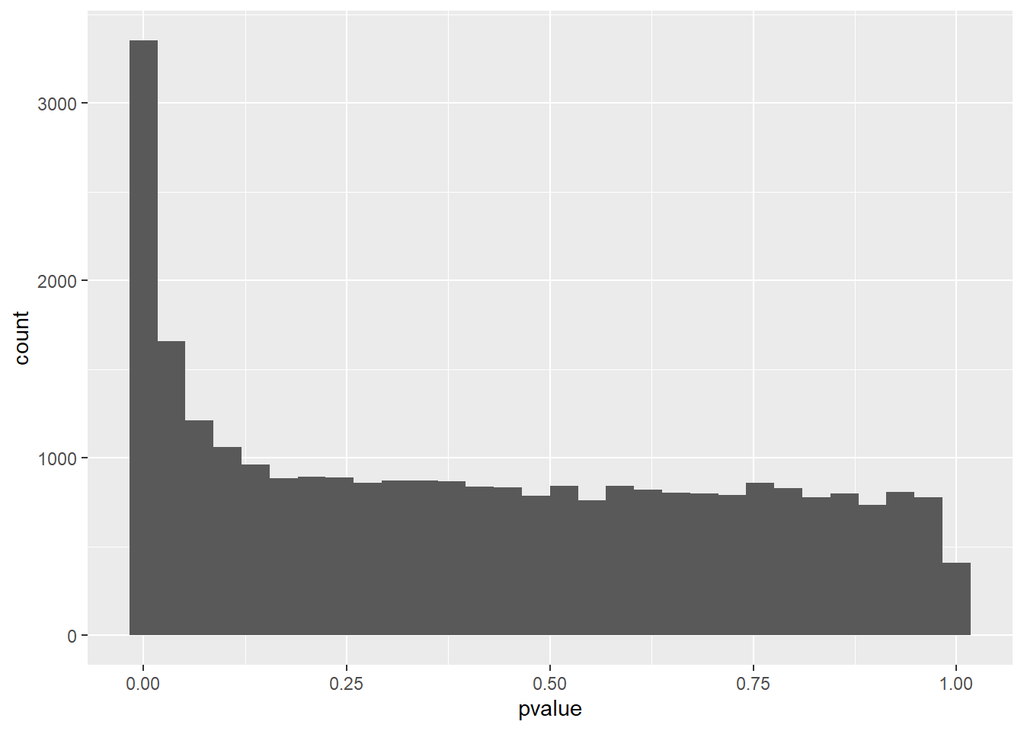

```r
ggplot(as(res, "data.frame"), aes(x = pvalue)) +
  geom_histogram()
```

### MA Plots

In DESeq2, the function plotMA shows the log2 fold changes attributable to a given variable over the mean of normalized counts for all the samples in the DESeqDataSet. Points will be colored red if the adjusted p value is less than 0.1. Points which fall out of the window are plotted as open triangles pointing either up or down.

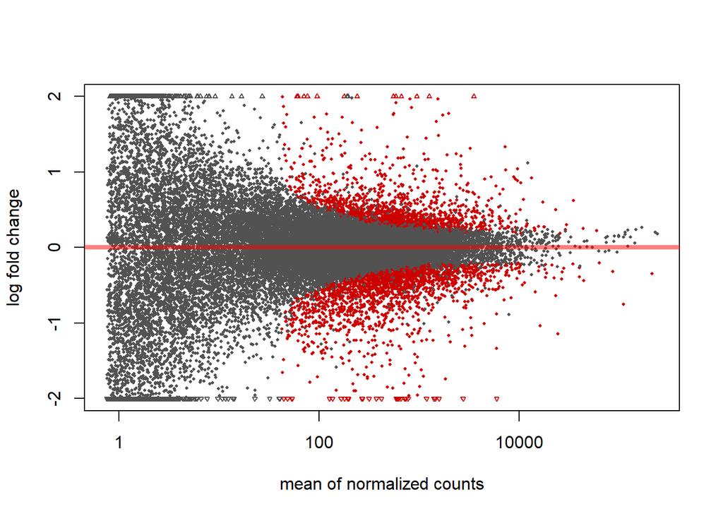

```r
DESeq2::plotMA(ddsDE, ylim = c(-2, 2))
```

It is more useful visualize the MA-plot for the shrunken log2 fold changes, which remove the noise associated with log2 fold changes from low count genes without requiring arbitrary filtering thresholds.

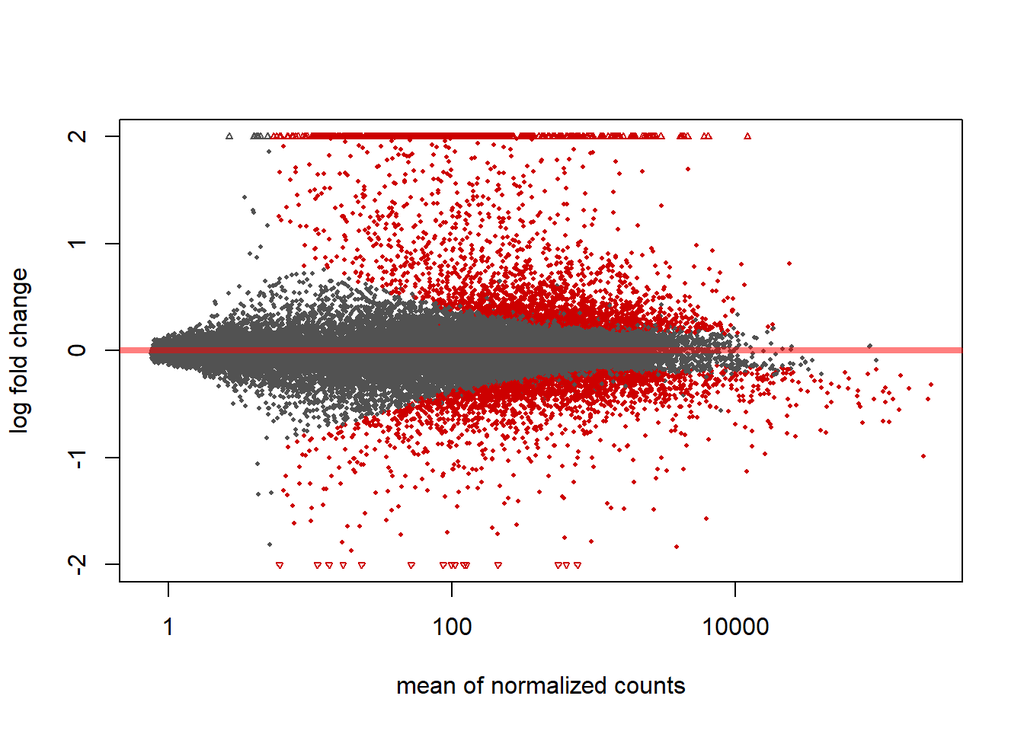

```r
plotMA(resLFC, ylim=c(-2,2))
```

## Principal Component Analysis

Provides information on how the samples are different

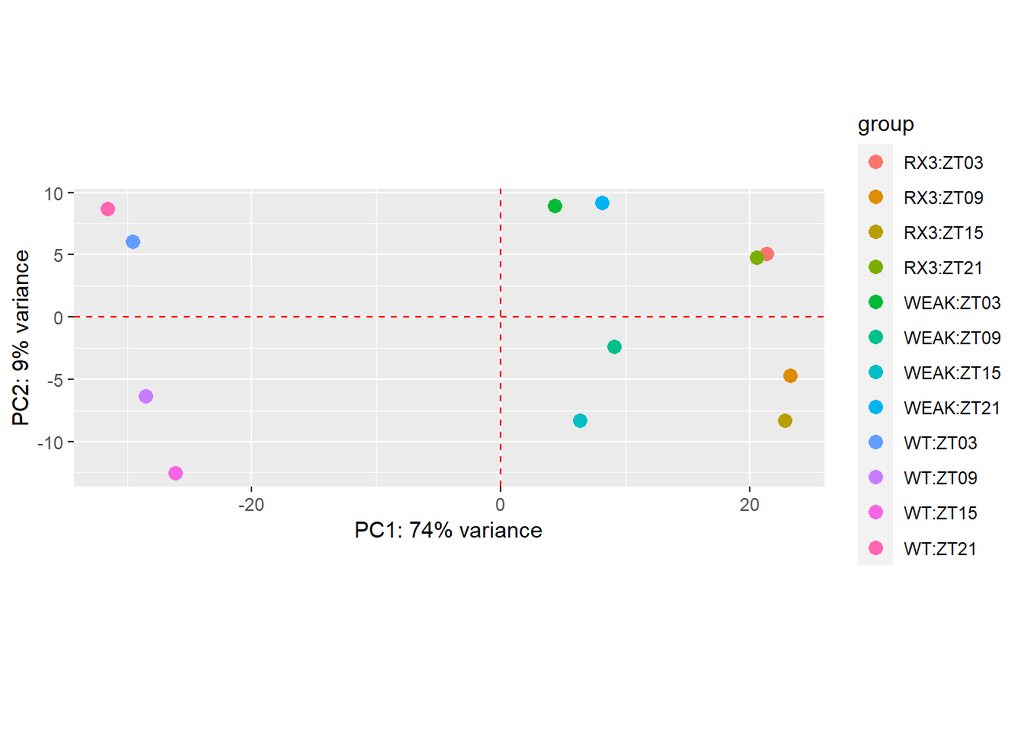

```r
ddsDE_rlog <- ddsDE %>%
  rlogTransformation()

ddsDE_rlog %>%
  DESeq2::plotPCA(intgroup = c("genotype_ch1", "zeitgeber_time_ch1")) +
  geom_vline(xintercept = 0, linetype = "dashed", colour = "red") +
  geom_hline(yintercept = 0, linetype = "dashed", colour = "red")
```

**Conclusion** There is a clear effect of genotype and zeitgeber on the differences in gene-expression, considering the point are distributed away from the centerpoint where PC1 = 0 and PC2 = 0 (crosshair dotted red lines)

### Heatmaps

To learn more on the gene expression differences, a heatmap can be very effective to communicate the results.

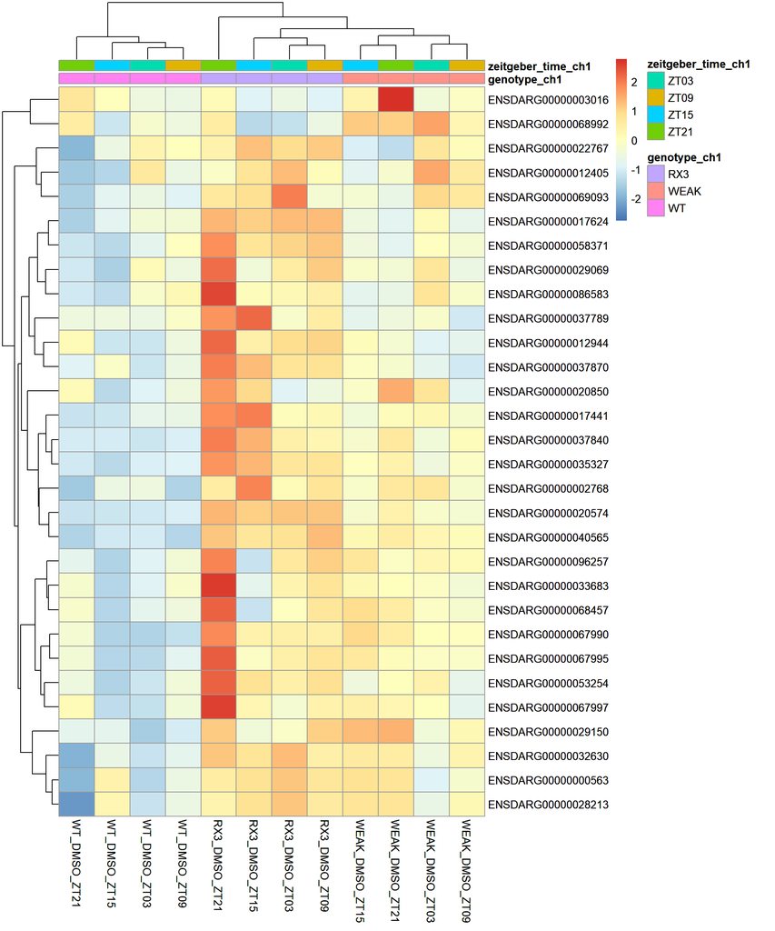

```r
library(pheatmap)
matrix_results <- assay(ddsDE_rlog)

ind <- matrix_results %>%
  rowMeans() %>%
  order(decreasing = TRUE) ## only the first 30 genes

top30 <- matrix_results[ind[1:30],]

heatmap <- pheatmap(top30,
                    scale = "row",
                    annotation_col = as.data.frame(
                      colData(ddsDE_rlog)[, c("genotype_ch1",
                                              "zeitgeber_time_ch1")]
                    ))
heatmap
```

### Annotated heatmap

We will have to use the specific Zebrafish dataset to get the right annotations for the zebrafish ENSEMBL ids. The Latin name for zebrafish is *Danio rerio* or *D. rerio* in short.

```r
library(biomaRt)
## all available marts
listMarts()
```

```
##                biomart                version
## 1 ENSEMBL_MART_ENSEMBL      Ensembl Genes 100
## 2   ENSEMBL_MART_MOUSE      Mouse strains 100
## 3     ENSEMBL_MART_SNP  Ensembl Variation 100
## 4 ENSEMBL_MART_FUNCGEN Ensembl Regulation 100
```

```r
## using a mart
mart <- biomaRt::useMart('ensembl')

## get all available datasets
datasets <- listDatasets(mart) %>%
  as_tibble()

## index for matching row that contain "Zebrafish" or "zebrafish"
ind <- str_detect(string = datasets$description, pattern = "(Z|z)ebrafish")

## get records
danio <- datasets[ind,]

## use the right mart
mart <- biomaRt::useMart('ensembl', dataset = danio$dataset)

attributes <- listAttributes(mart = mart) %>% as_tibble()

## search for gene_name or symbol
ind_attrib <- str_detect(
  string = attributes$name,
  pattern = "(gene_name|symbol)"
)

attributes[ind_attrib,]
```

```
## # A tibble: 200 x 3
##    name                             description                       page
##    <chr>                            <chr>                             <chr>
##  1 external_gene_name               Gene name                         feature_p~
##  2 hgnc_symbol                      HGNC symbol                       feature_p~
##  3 uniprot_gn_symbol                UniProtKB Gene Name symbol        feature_p~
##  4 wikigene_name                    WikiGene name                     feature_p~
##  5 zfin_id_symbol                   ZFIN symbol                       feature_p~
##  6 external_gene_name               Gene name                         structure
##  7 external_gene_name               Gene name                         homologs
##  8 cabingdonii_homolog_associated_~ Abingdon island giant tortoise g~ homologs
##  9 gagassizii_homolog_associated_g~ Agassiz's desert tortoise gene n~ homologs
## 10 mspretus_homolog_associated_gen~ Algerian mouse gene name          homologs
## # ... with 190 more rows
```

```r
annotations <-
  getBM(
    attributes=c('external_gene_name', 'ensembl_gene_id'),
    filters = 'ensembl_gene_id',
    values = rownames(top30),
    mart = mart)
```

**Conclusion** On the basis of the top30 genes and theri respective ensembl_ids, we find 27 annotated genes. Let’s plot a new heatmap showing those with the 27 new names

```r
top30_df <- top30 %>%
  as.data.frame() %>%
  dplyr::mutate(ensembl_gene_id = rownames(.))

annot_27 <- left_join(annotations, top30_df)

top_27_annot <- as.matrix(annot_27[, -c(1:2)])
rownames(top_27_annot) <- annot_27$external_gene_name
```

## Annotated heatmap

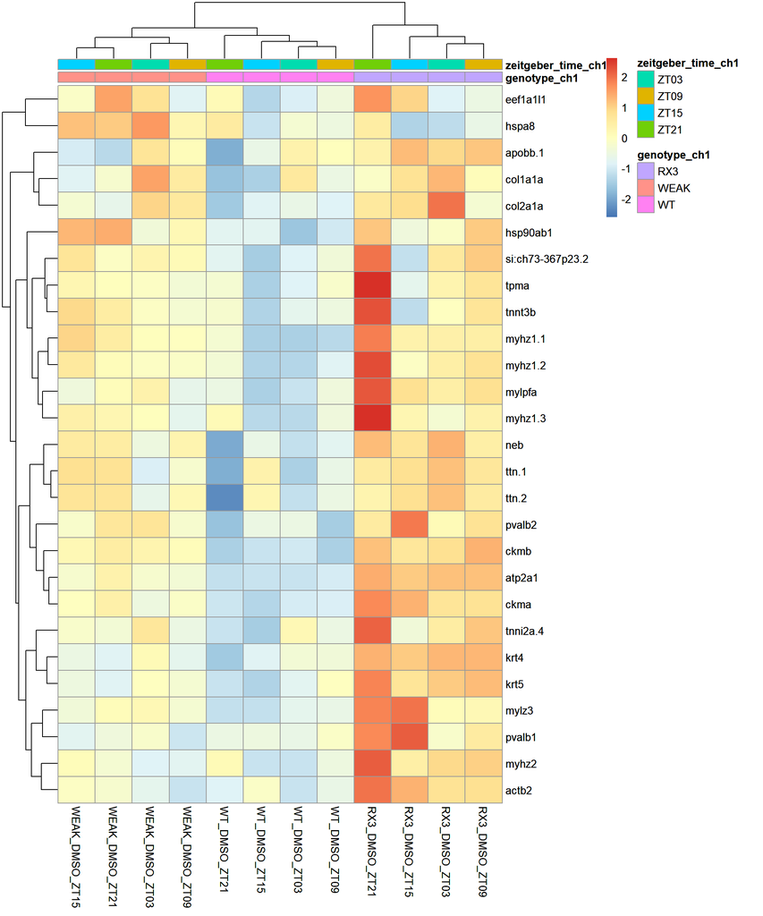

```r
heatmap <- pheatmap(top_27_annot,
                    scale = "row",
                    annotation_col = as.data.frame(
                      colData(ddsDE_rlog)[, c("genotype_ch1",
                                              "zeitgeber_time_ch1")]))

heatmap
```